# Tugas

```r
library(dLagM)
library(dynlm)
library(MLmetrics)
library(lmtest)
library(car)
```

# Latihan 1

## Import Data

```r
# Membuat dataframe di R
data_market <- data.frame(
  Period = 1:20,
  Market_share = c(
    3.63, 4.20, 3.33, 4.54, 2.89, 4.87, 4.90, 5.29, 6.18, 7.20, # Periode 1-10
    7.25, 6.09, 6.80, 8.65, 8.43, 8.29, 7.18, 7.90, 8.45, 8.23  # Periode 11-20
  ),
  Price = c(
    0.97, 0.95, 0.99, 0.91, 0.98, 0.90, 0.89, 0.86, 0.85, 0.82, # Periode 1-10
    0.79, 0.83, 0.81, 0.77, 0.76, 0.80, 0.83, 0.79, 0.76, 0.78  # Periode 11-20
  )
)

# Melihat isi dataframe
print(data_market)
```

```
##    Period Market_share Price
## 1       1         3.63  0.97
## 2       2         4.20  0.95
## 3       3         3.33  0.99
## 4       4         4.54  0.91
## 5       5         2.89  0.98
## 6       6         4.87  0.90
## 7       7         4.90  0.89
## 8       8         5.29  0.86
## 9       9         6.18  0.85
## 10     10         7.20  0.82
## 11     11         7.25  0.79
## 12     12         6.09  0.83
## 13     13         6.80  0.81
## 14     14         8.65  0.77
## 15     15         8.43  0.76
## 16     16         8.29  0.80
## 17     17         7.18  0.83
## 18     18         7.90  0.79
## 19     19         8.45  0.76
## 20     20         8.23  0.78
```

## Splitting Data

```r
# SPLIT DATA (70% Train, 30% Test)
train <- data_market[1:14, ]
test  <- data_market[15:20, ]
```

```r
train.ts<-ts(train)
test.ts<-ts(test)
data_market.ts<-ts(data_market)
```

## Model Kyock (Infinite Distributed Lag)

```r
#MODEL KOYCK
model.koyck <- koyckDlm(x = train$Price,y = train$Market_share)
summary(model.koyck)
```

```
##
## Call:
## "Y ~ (Intercept) + Y.1 + X.t"
##
## Residuals:
##      Min       1Q   Median       3Q      Max
## -0.87495 -0.31133  0.02771  0.25593  1.06752
##
## Coefficients:
##             Estimate Std. Error t value Pr(>|t|)
## (Intercept)  17.0984    15.0126   1.139    0.281
## Y.1           0.2971     0.5469   0.543    0.599
## X.t         -14.9818    14.0158  -1.069    0.310
##
## Residual standard error: 0.5767 on 10 degrees of freedom
## Multiple R-Squared:   0.9,   Adjusted R-squared:  0.88
## Wald test: 29.43 on 2 and 10 DF,  p-value: 6.456e-05
##
## Diagnostic tests:
## NULL
##
##                             alpha      beta       phi
## Geometric coefficients:  24.32425 -14.98175 0.2970638
```

```r
AIC(model.koyck)
```

```
## [1] 27.17193
```

```r
BIC(model.koyck)
```

```
## [1] 29.43173
```

```r
fore.koyck <- forecast(model = model.koyck, x=test$Price, h=6)
fore.koyck
```

```
## $forecasts
## [1] 8.281864 7.573233 6.913273 7.316492 7.885727 7.755191
##
## $call
## forecast.koyckDlm(model = model.koyck, x = test$Price, h = 6)
##
## attr(,"class")
## [1] "forecast.koyckDlm" "dLagM"
```

```r
mape.koyck <- MAPE(fore.koyck$forecasts, test$Market_share)
mape.koyck #data test
```

```
## [1] 0.05658583
```

## Regression with Distributed Lag

### penentuan lag optimum

```r
finiteDLMauto(formula = Market_share ~ Price,
              data = data.frame(train), q.min = 1, q.max = 12,
              model.type = "dlm", error.type = "AIC", trace = TRUE)
```

```
##    q - k    MASE      AIC      BIC   GMRAE   MBRAE R.Adj.Sq Ljung-Box
## 6      6 0.00000     -Inf     -Inf 0.00000 0.00000      NaN       NaN
## 7      7 0.00000     -Inf     -Inf 0.00000 0.00000      NaN       NaN
## 8      8 0.00000     -Inf     -Inf 0.00000 0.00000      NaN       NaN
## 9      9 0.00000     -Inf     -Inf 0.00000 0.00000      NaN       NaN
## 10    10 0.00000     -Inf     -Inf 0.00000 0.00000      NaN       NaN
## 11    11 0.00000     -Inf     -Inf 0.00000 0.00000      NaN       NaN
## 12    12 0.00000     -Inf     -Inf 0.00000 0.00000      NaN       NaN
## 5      5 0.25971 14.51079 16.08859 0.44616 0.22230  0.85752 0.1176490
## 3      3 0.25900 14.51252 16.89990 0.43933 0.18547  0.94676 0.8298994
## 4      4 0.26947 16.46363 18.58173 0.38193 0.18959  0.92787 0.9309928
## 1      1 0.33471 19.48993 21.74973 0.44920 0.39811  0.93356 0.6204697
## 2      2 0.30975 20.31532 22.73986 0.36126 0.59945  0.92706 0.9843456
```

## Pemodelan

```r
model.dlm <- dlm(x = train$Price,y = train$Market_share , q = 3)
summary(model.dlm)
```

```
##
## Call:
## lm(formula = model.formula, data = design)
##
## Residuals:
##     Min      1Q  Median      3Q     Max
## -0.3416 -0.2283 -0.1383  0.2123  0.4948
##
## Coefficients:
##             Estimate Std. Error t value Pr(>|t|)
## (Intercept)   27.552      1.720  16.021 3.76e-06 ***
## x.t          -26.867      4.261  -6.305 0.000743 ***
## x.1            4.430      3.655   1.212 0.270987
## x.2            2.519      3.717   0.678 0.523289
## x.3           -5.335      3.757  -1.420 0.205417
## ---
## Signif. codes:  0 '***' 0.001 '**' 0.01 '*' 0.05 '.' 0.1 ' ' 1
##
## Residual standard error: 0.3673 on 6 degrees of freedom
## Multiple R-squared:  0.9681, Adjusted R-squared:  0.9468
## F-statistic: 45.46 on 4 and 6 DF,  p-value: 0.0001272
##
## AIC and BIC values for the model:
##        AIC     BIC
## 1 14.51252 16.8999
```

```r
fore.dlm <- forecast(model = model.dlm, x=test$Price, h=6)
fore.dlm
```

```
## $forecasts
## [1] 8.156937 7.043911 6.603318 7.964993 8.455959 7.524925
##
## $call
## forecast.dlm(model = model.dlm, x = test$Price, h = 6)
##
## attr(,"class")
## [1] "forecast.dlm" "dLagM"
```

```r
mape.dlm <- MAPE(fore.dlm$forecasts, test$Market_share)
mape.dlm
```

```
## [1] 0.05960423
```

## ARDL

### Pemodelan

```r
model.ardl1 <- ardlDlm(x = train$Price,y = train$Market_share , p = 1 , q = 1)
summary(model.ardl1)
```

```
##
## Time series regression with "ts" data:
## Start = 2, End = 14
##
## Call:
## dynlm(formula = as.formula(model.text), data = data, start = 1)
##
## Residuals:
##     Min      1Q  Median      3Q     Max
## -0.5041 -0.3200 -0.0978  0.3348  0.7436
##
## Coefficients:
##             Estimate Std. Error t value Pr(>|t|)
## (Intercept)  18.3868     9.8634   1.864   0.0952 .
## X.t         -23.5507     2.9997  -7.851 2.57e-05 ***
## X.1           7.0049     9.0837   0.771   0.4604
## Y.1           0.2911     0.4102   0.710   0.4959
## ---
## Signif. codes:  0 '***' 0.001 '**' 0.01 '*' 0.05 '.' 0.1 ' ' 1
##
## Residual standard error: 0.4403 on 9 degrees of freedom
## Multiple R-squared:  0.9476, Adjusted R-squared:  0.9301
## F-statistic: 54.22 on 3 and 9 DF,  p-value: 4.379e-06
```

### Lag Optimum

```r
model.ardl1.opt <- ardlBoundOrders(
  data = train,
  ic = "AIC",
  formula = Market_share ~ Price,
  max.p = 5,
  max.q = 5,
  FullSearch = TRUE
)

model.ardl1.opt
```

```
## $p
##   Price
## 1     2
##
## $q
## [1] 1
##
## $Stat.table
##          q = 1    q = 2    q = 3 q = 4 q = 5
## p = 1 15.43711 13.19052 15.39413    NA    NA
## p = 2 13.00914 13.54219 14.07171    NA    NA
## p = 3 13.72401 13.72401       NA    NA    NA
##
## $min.Stat
## [1] 13.00914
```

### Pemodelan Dengan Lag terbaik

```r
model.ardl1.terbaik <- ardlDlm(
  formula = Market_share ~ Price,
  data = train,
  p = 2,
  q = 1
)

summary(model.ardl1.terbaik)
```

```
##
## Time series regression with "ts" data:
## Start = 3, End = 14
##
## Call:
## dynlm(formula = as.formula(model.text), data = data)
##
## Residuals:
##      Min       1Q   Median       3Q      Max
## -0.48332 -0.24913 -0.09692  0.27731  0.72554
##
## Coefficients:
##                Estimate Std. Error t value Pr(>|t|)
## (Intercept)     20.2729    11.0891   1.828  0.11024
## Price.t        -23.5242     4.5206  -5.204  0.00125 **
## Price.1          5.4604    10.4943   0.520  0.61888
## Price.2         -0.3172     4.7133  -0.067  0.94822
## Market_share.1   0.2361     0.4593   0.514  0.62307
## ---
## Signif. codes:  0 '***' 0.001 '**' 0.01 '*' 0.05 '.' 0.1 ' ' 1
##
## Residual standard error: 0.478 on 7 degrees of freedom
## Multiple R-squared:  0.9489, Adjusted R-squared:  0.9197
## F-statistic: 32.49 on 4 and 7 DF,  p-value: 0.0001305
```

```r
fore.ardl1 <- forecast(
  model = model.ardl1.terbaik,
  x = test$Price,
  h = 6
)

fore.ardl1
```

```
## $forecasts
## [1] 8.384424 7.338837 6.607835 7.527335 8.222223 7.764681
##
## $call
## forecast.ardlDlm(model = model.ardl1.terbaik, x = test$Price,
##     h = 6)
##
## attr(,"class")
## [1] "forecast.ardlDlm" "dLagM"
```

```r
mape.ardl1 <- MAPE(fore.ardl1$forecasts, test$Market_share)
mape.ardl1
```

```
## [1] 0.05508323
```

## Perbandingan Model

```r
akurasi <- matrix(c(mape.koyck, mape.dlm, mape.ardl1))
row.names(akurasi)<- c("Koyck","DLM","ARDL")
colnames(akurasi) <- c("MAPE")
akurasi
```

```
##             MAPE
## Koyck 0.05658583
## DLM   0.05960423
## ARDL  0.05508323
```

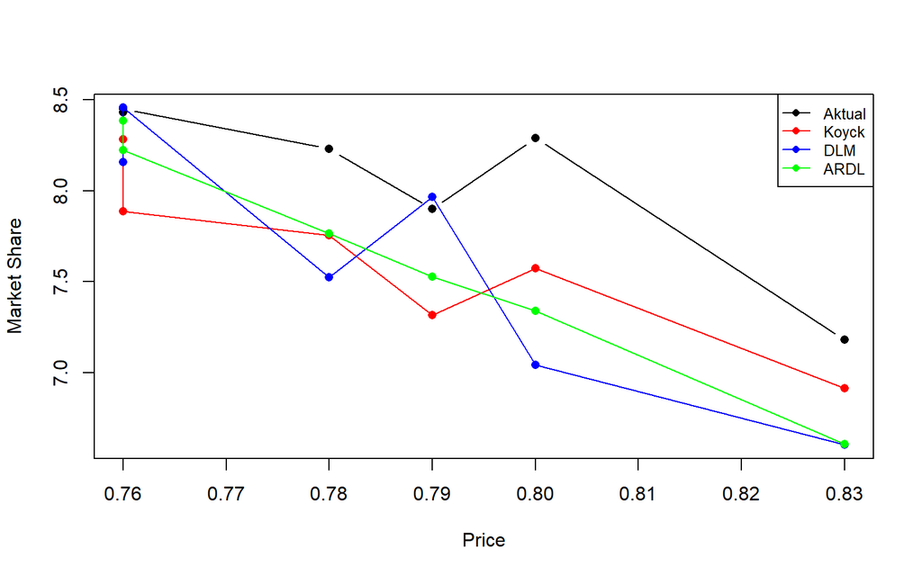

```r
# 1. Urutkan data berdasarkan Price dari yang terkecil ke terbesar agar garis tidak zig-zag
idx <- order(test$Price)

p_sort       <- test$Price[idx]
aktual_sort  <- test$Market_share[idx]
koyck_sort   <- fore.koyck$forecasts[idx]
dlm_sort     <- fore.dlm$forecasts[idx]
ardl_sort    <- fore.ardl1$forecasts[idx]

# 2. Atur layout grafik tunggal
par(mfrow=c(1,1))

# 3. Plot data aktual yang sudah diurutkan
plot(p_sort, aktual_sort, type="b", col="black", pch=16,
     xlab = "Price", ylab = "Market Share",
     ylim = range(c(aktual_sort, koyck_sort, dlm_sort, ardl_sort), na.rm = TRUE))

# 4. Tambahkan garis ramalan dari masing-masing model
points(p_sort, koyck_sort, col="red", pch=16);   lines(p_sort, koyck_sort, col="red", lty=1)
points(p_sort, dlm_sort, col="blue", pch=16);    lines(p_sort, dlm_sort, col="blue", lty=1)
points(p_sort, ardl_sort, col="green", pch=16);  lines(p_sort, ardl_sort, col="green", lty=1)

# 5. Legenda disesuaikan dengan 4 model yang benar-benar di-plot
legend("topright",  # Pindahkan ke kanan atas (atau "bottomright" / "bottomleft")
       legend = c("Aktual", "Koyck", "DLM", "ARDL"),
       lty = 1, pch = 16,
       col = c("black", "red", "blue", "green"),
       cex = 0.8)
```

Berdasarkan hasil perbandingan akurasi peramalan menggunakan Mean Absolute Percentage Error (MAPE), diperoleh nilai MAPE untuk model Koyck sebesar 0,05658583 atau 5,66%, model DLM sebesar 0,05960423 atau 5,96%, dan model ARDL sebesar 0,05508323 atau 5,51%. Dari ketiga model tersebut, model ARDL memiliki nilai MAPE paling rendah, yaitu sebesar 5,51%. Hal ini menunjukkan bahwa model ARDL menghasilkan tingkat kesalahan peramalan paling kecil sehingga memiliki akurasi peramalan yang paling baik dibandingkan model Koyck dan DLM.

Dengan demikian, berdasarkan kriteria nilai MAPE terkecil, model ARDL dipilih sebagai model terbaik untuk melakukan peramalan Market Share. Hasil peramalan menggunakan model ARDL(2,1) untuk enam periode ke depan menghasilkan nilai prediksi berturut-turut sebesar 8,3844; 7,3388; 6,6078; 7,5273; 8,2222; dan 7,7647.

# Latihan 2

## Input Data

```r
# Membuat dataframe untuk data Sales dan Advertising (1975 - 2014)
data_sales <- data.frame(
  Year = 1975:2014,
  Sales = c(
    11.7, 12.0, 12.3, 12.8, 13.1, 13.6, 13.9, 14.4, 14.7, 15.3, # 1975-1984
    15.5, 15.8, 16.1, 16.6, 16.9, 16.7, 16.9, 17.4, 17.6, 17.9, # 1985-1994
    18.0, 17.9, 18.0, 18.2, 18.2, 18.3, 18.6, 19.2, 19.3, 19.5, # 1995-2004
    19.2, 19.3, 19.5, 20.0, 20.0, 19.9, 19.8, 19.9, 20.2, 21.0  # 2005-2014
  ),
  Advertising = c(
    9.4, 9.6, 10.0, 10.4, 10.8, 10.9, 11.7, 12.2, 12.5, 12.9, # 1975-1984
    13.0, 13.2, 13.8, 14.2, 14.6, 14.4, 15.0, 15.4, 15.7, 15.9, # 1985-1994
    15.9, 16.0, 16.3, 16.2, 16.8, 17.3, 17.6, 18.1, 18.3, 18.5, # 1995-2004
    18.7, 18.9, 19.2, 20.0, 20.0, 20.3, 20.4, 21.0, 21.5, 22.1  # 2005-2014
  )
)

# Melihat ringkasan atau isi data
head(data_sales)
```

```
##   Year Sales Advertising
## 1 1975  11.7         9.4
## 2 1976  12.0         9.6
## 3 1977  12.3        10.0
## 4 1978  12.8        10.4
## 5 1979  13.1        10.8
## 6 1980  13.6        10.9
```

```r
tail(data_sales)
```

```
##    Year Sales Advertising
## 35 2009  20.0        20.0
## 36 2010  19.9        20.3
## 37 2011  19.8        20.4
## 38 2012  19.9        21.0
## 39 2013  20.2        21.5
## 40 2014  21.0        22.1
```

## Splitting Data

```r
# Data training: 1975-2008
train <- subset(data_sales, Year <= 2008)

# Data testing: 2009-2014
test <- subset(data_sales, Year >= 2009)

nrow(train)
```

```
## [1] 34
```

```r
nrow(test)
```

```
## [1] 6
```

## Mencari Lag Optimal

```r
model.ardl2.opt <- ardlBoundOrders(
  data = train,
  ic = "AIC",
  formula = Sales ~ Advertising,
  max.p = 14,
  max.q = 14,
  FullSearch = TRUE
)

model.ardl2.opt
```

```
## $p
##   Advertising
## 1           8
##
## $q
## [1] 10
##
## $Stat.table
##             q = 1      q = 2      q = 3      q = 4      q = 5       q = 6
## p = 1  -16.274202 -13.374247 -11.865310 -10.881752  -7.176121   -7.470548
## p = 2  -14.462764 -12.573364 -10.792945  -9.618705  -5.983322   -6.071696
## p = 3   -9.836158  -9.836158 -13.019585 -11.207790  -7.473175   -6.847205
## p = 4  -12.775044 -11.195561 -11.195561  -9.363324  -5.666834   -5.094991
## p = 5   -8.762715  -6.844314  -9.361784  -9.361784  -9.267326   -9.415485
## p = 6   -8.837851  -7.037666  -8.805626  -7.027957  -7.027957   -7.420729
## p = 7   -6.888505  -4.948209  -6.538932  -4.930069  -8.113044   -8.113044
## p = 8  -10.556476  -9.193061  -7.524165  -5.721293  -9.593257  -18.578723
## p = 9  -17.229995 -15.255222 -16.665287 -20.912665 -36.198829 -124.603487
## p = 10 -15.230083 -13.258628 -12.042044 -13.824714 -21.508123  -21.352735
## p = 11  -6.538664  -6.920999  -6.139385  -4.168984 -51.304498          NA
## p = 12 -20.346909 -18.357575 -21.044678         NA         NA          NA
## p = 13 -40.859244         NA         NA         NA         NA          NA
##              q = 7       q = 8       q = 9      q = 10    q = 11     q = 12
## p = 1    -6.534862   -8.048245   -6.303362  -15.495447 -14.58136  -9.769076
## p = 2    -5.188455   -7.811724   -5.148884  -14.545903 -14.17532  -9.843338
## p = 3    -5.252489   -6.964659   -8.161292  -12.547895 -18.49246 -16.391002
## p = 4    -3.512112   -5.027402   -6.980486  -10.720303 -23.68648 -51.411400
## p = 5    -6.619568   -8.303335   -9.019744   -8.773644 -21.68701         NA
## p = 6    -4.787194   -6.837138   -8.260543   -7.428001 -51.85379         NA
## p = 7   -19.396087  -19.391803  -29.010528  -35.378398        NA         NA
## p = 8   -18.578723  -22.052307 -107.939610 -253.592901        NA         NA
## p = 9  -124.712623 -124.712623 -123.527090          NA        NA         NA
## p = 10  -72.367772          NA          NA          NA        NA         NA
## p = 11          NA          NA          NA          NA        NA         NA
## p = 12          NA          NA          NA          NA        NA         NA
## p = 13          NA          NA          NA          NA        NA         NA
##           q = 13 q = 14
## p = 1  -6.985543     NA
## p = 2  -5.638039     NA
## p = 3         NA     NA
## p = 4         NA     NA
## p = 5         NA     NA
## p = 6         NA     NA
## p = 7         NA     NA
## p = 8         NA     NA
## p = 9         NA     NA
## p = 10        NA     NA
## p = 11        NA     NA
## p = 12        NA     NA
## p = 13        NA     NA
##
## $min.Stat
## [1] -253.5929
```

## Pemodelan dengan lag optimal

```r
model.ardl2.terbaik <- ardlDlm(
  formula = Sales ~ Advertising,
  data = train,
  p = 8,
  q = 10
)

summary(model.ardl2.terbaik)
```

```
##
## Time series regression with "ts" data:
## Start = 11, End = 34
##
## Call:
## dynlm(formula = as.formula(model.text), data = data)
##
## Residuals:
##         11         12         13         14         15         16         17
##  0.0601767 -0.0530780 -0.0251924 -0.0387423  0.0871028 -0.0414374 -0.0746324
##         18         19         20         21         22         23         24
##  0.0435453 -0.0246700  0.0057579  0.0991862 -0.0087331  0.0843172 -0.0284780
##         25         26         27         28         29         30         31
## -0.0007303 -0.0332605 -0.0317947  0.0314113 -0.0956777  0.0788006 -0.0788199
##         32         33         34
##  0.0415350 -0.0348509  0.0382645
##
## Coefficients:
##               Estimate Std. Error t value Pr(>|t|)
## (Intercept)     2.8243     2.0469   1.380   0.2398
## Advertising.t   0.7722     0.2033   3.798   0.0191 *
## Advertising.1  -0.6634     0.3547  -1.870   0.1348
## Advertising.2   0.2934     0.3495   0.839   0.4485
## Advertising.3   0.1970     0.3218   0.612   0.5735
## Advertising.4  -0.4323     0.2666  -1.622   0.1802
## Advertising.5   0.2452     0.2217   1.106   0.3308
## Advertising.6  -0.2901     0.1941  -1.495   0.2093
## Advertising.7   0.4212     0.2349   1.793   0.1474
## Advertising.8  -0.5675     0.2257  -2.514   0.0658 .
## Sales.1         0.8929     0.3007   2.969   0.0412 *
## Sales.2        -0.7214     0.3495  -2.064   0.1079
## Sales.3         0.2780     0.3556   0.782   0.4780
## Sales.4         0.2416     0.3218   0.751   0.4945
## Sales.5        -0.6551     0.3204  -2.045   0.1103
## Sales.6         0.8312     0.3197   2.600   0.0600 .
## Sales.7        -0.7678     0.4588  -1.673   0.1696
## Sales.8         0.4544     0.4901   0.927   0.4063
## Sales.9         0.6499     0.4030   1.612   0.1822
## Sales.10       -0.3488     0.2788  -1.251   0.2790
## ---
## Signif. codes:  0 '***' 0.001 '**' 0.01 '*' 0.05 '.' 0.1 ' ' 1
##
## Residual standard error: 0.135 on 4 degrees of freedom
## Multiple R-squared:  0.998,  Adjusted R-squared:  0.9885
## F-statistic: 105.2 on 19 and 4 DF,  p-value: 0.0001965
```

## Peramalan

```r
fore.ardl <- forecast(
  model = model.ardl2.terbaik,
  x = test$Advertising,
  h = 6
)

fore.ardl$forecasts
```

```
## [1] 19.45355 19.63392 20.10669 20.62209 20.53637 20.64218
```

```r
hasil.forecast <- data.frame(
  Year = test$Year,
  Sales_Aktual = test$Sales,
  Sales_Forecast = as.numeric(fore.ardl$forecasts)
)

hasil.forecast
```

```
##   Year Sales_Aktual Sales_Forecast
## 1 2009         20.0       19.45355
## 2 2010         19.9       19.63392
## 3 2011         19.8       20.10669
## 4 2012         19.9       20.62209
## 5 2013         20.2       20.53637
## 6 2014         21.0       20.64218
```

## Akurasi Model

```r
mape.ardl <- MAPE(
  fore.ardl$forecasts,
  test$Sales
)

mape.ardl
```

```
## [1] 0.02102652
```

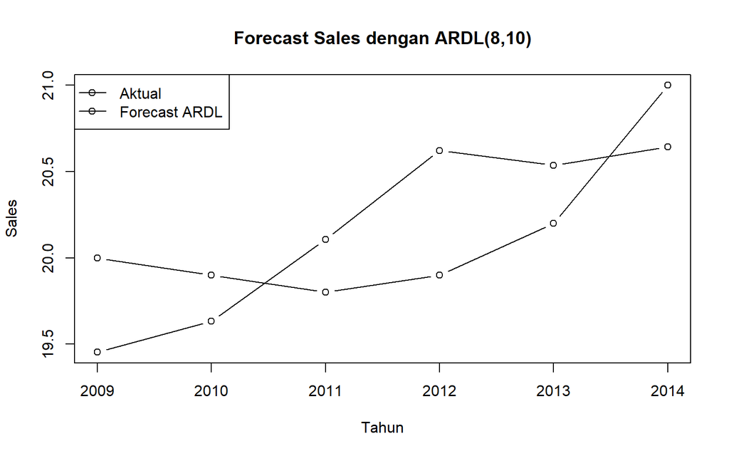

```r
plot(
  test$Year,
  test$Sales,
  type = "b",
  ylim = range(c(test$Sales, fore.ardl$forecasts)),
  xlab = "Tahun",
  ylab = "Sales",
  main = "Forecast Sales dengan ARDL(8,10)"
)

lines(
  test$Year,
  fore.ardl$forecasts,
  type = "b"
)

legend(
  "topleft",
  legend = c("Aktual", "Forecast ARDL"),
  lty = 1,
  pch = 1
)
```

Berdasarkan kriteria AIC, model terbaik yang diperoleh adalah ARDL(8,10). Model tersebut kemudian digunakan untuk melakukan forecasting Sales pada periode 2009–2014. Hasil evaluasi menunjukkan nilai MAPE sebesar 2,10%, sehingga model ARDL(8,10) memiliki tingkat akurasi prediksi yang sangat baik.